# DESEQ2 - Initial

# 5. Save Results

Saving to .rds compresses all of the data into one file that can be re-imported into RStudio, without having to re-run the very long commands above. It does not re-instate the whole image of the environment, just the output of auto_generate_DE_results() which has been unlisted so that every entry is named.

***The call to saveRDS() can take ~ 10 minutes and still produces a large file, particularly if many regions and samples are included. E.g. 40 samples x 6 regions = ~2.0 GB

```r
# Defaults to NOT RUN when running whole document.
#Save file as progress. Can be used as input instead of re-running all of the DESEQ functions.
saveRDS(DE_out, file = "./outputs/DE_out_file_testing.rds")

#to re-import to environment:
#DE_out2 <- readRDS(file = "./outputs/DE_out_file.rds")
```

# 6. Accessing Results

Overall, results can be accessed by using $ notation to navigate through the list. Search, unlisting and reduction techniques help to select data of interest.

The first level of the list can be accessed by using the $ sign. To see all available options use names().

```r
DE_out %>% names()
```

```
[1] "ARC_DESeq2_Output" "DUO_DESeq2_Output" "LHA_DESeq2_Output" "LIV_DESeq2_Output" "RUM_DESeq2_Output"
[6] "VMH_DESeq2_Output"
```

Multiple $ can be used for recurring levels. Pressing the Tab button on keyboard shows options as well. Likewise, if a dataframe is the lowest level of the list that is accessed with a $, then it will also allow the column names to be accessed with $ as well.

```r
#Access a dataframe
DE_out$ARC_DESeq2_Output$DESeq2_annot_df$`ARC_HCP.HP.RMEI vs ARC_HCP.HP.UMEI`

#Access a column in a dataframe
DE_out$ARC_DESeq2_Output$DESeq2_annot_df$`ARC_HCP.HP.RMEI vs ARC_HCP.HP.UMEI`$gene_ensembl
```

Using a call to purrr::map with a string will iterate over each of the entries in the first level of the list and search within those lists to return a new list of only entries with matching names.

```r
#Check what second level entries exist
DE_out$ARC_DESeq2_Output %>% names()
```

```
[1] "dds_wald_object"   "DESeq2_res_object" "DESeq2_annot_df"   "pairwise_plots"    "overall_plots"
[6] "normalised_data"   "PIF"
```

```r
#The string in call to map must be one of the options produced from above.
#This works because each Region's entry has the same underlying structure.
sample_accessed_object <-  DE_out %>%
  purrr::map("dds_wald_object")

sample_accessed_object %>%  str(max.level = 2)
```

```
List of 6
 $ ARC_DESeq2_Output:Formal class 'DESeqDataSet' [package "DESeq2"] with 8 slots
 $ DUO_DESeq2_Output:Formal class 'DESeqDataSet' [package "DESeq2"] with 8 slots
 $ LHA_DESeq2_Output:Formal class 'DESeqDataSet' [package "DESeq2"] with 8 slots
 $ LIV_DESeq2_Output:Formal class 'DESeqDataSet' [package "DESeq2"] with 8 slots
 $ RUM_DESeq2_Output:Formal class 'DESeqDataSet' [package "DESeq2"] with 8 slots
 $ VMH_DESeq2_Output:Formal class 'DESeqDataSet' [package "DESeq2"] with 8 slots
```

A call to unlist(recursive = FALSE) removes the first layer of the list, which is often helpful if it returns a further list. E.g. there are 60 results objects when there are 10 pairwise comparisons x 6 regions.

```r
DE_out %>%
  purrr::map("DESeq2_res_object") %>%
  unlist(recursive = FALSE) %>%
  str(max.level = 2, list.len = 10) #shows first 10 of 60 for easier reading
```

```
List of 60
 $ ARC_DESeq2_Output.ARC_HCP.HP.RMEI vs ARC_HCP.HP.UMEI:Formal class 'DESeqResults' [package "DESeq2"] with 7 slots
 $ ARC_DESeq2_Output.ARC_HCP.HP.RMEI vs ARC_HCP.LP.UMEI:Formal class 'DESeqResults' [package "DESeq2"] with 7 slots
 $ ARC_DESeq2_Output.ARC_HCP.HP.RMEI vs ARC_LCP.HP.UMEI:Formal class 'DESeqResults' [package "DESeq2"] with 7 slots
 $ ARC_DESeq2_Output.ARC_HCP.HP.RMEI vs ARC_LCP.LP.UMEI:Formal class 'DESeqResults' [package "DESeq2"] with 7 slots
 $ ARC_DESeq2_Output.ARC_HCP.HP.UMEI vs ARC_HCP.LP.UMEI:Formal class 'DESeqResults' [package "DESeq2"] with 7 slots
 $ ARC_DESeq2_Output.ARC_HCP.HP.UMEI vs ARC_LCP.HP.UMEI:Formal class 'DESeqResults' [package "DESeq2"] with 7 slots
 $ ARC_DESeq2_Output.ARC_HCP.HP.UMEI vs ARC_LCP.LP.UMEI:Formal class 'DESeqResults' [package "DESeq2"] with 7 slots
 $ ARC_DESeq2_Output.ARC_HCP.LP.UMEI vs ARC_LCP.HP.UMEI:Formal class 'DESeqResults' [package "DESeq2"] with 7 slots
 $ ARC_DESeq2_Output.ARC_HCP.LP.UMEI vs ARC_LCP.LP.UMEI:Formal class 'DESeqResults' [package "DESeq2"] with 7 slots
 $ ARC_DESeq2_Output.ARC_LCP.HP.UMEI vs ARC_LCP.LP.UMEI:Formal class 'DESeqResults' [package "DESeq2"] with 7 slots
  [list output truncated]
```

## DE

|  | gene_ensembl | gene_name | description | baseMean | log2FoldChange | lfcSE | stat | pvalue | padj | weight | zPIF |
| --- | --- | --- | --- | --- | --- | --- | --- | --- | --- | --- | --- |
| 1 | ENSOARG00000003006 | ENSOARG00000003006 | agouti related neuropeptide [Source:NCBI gene (formerly Entrezgene);Acc:443269] | 3641.75889 | 2.4118861 | 0.42820322 | 5.632573 | 1.775402e-08 | 9.704323e-05 | 3.0331461 | 17.132668 |
| 2 | ENSOARG00000010915 | ENSOARG00000010915 | neuropeptide Y [Source:HGNC Symbol;Acc:HGNC:7955] | 3430.33233 | 1.8369092 | 0.39553092 | 4.644161 | 3.414613e-06 | 6.428203e-03 | 1.6564069 | 13.291520 |
| 3 | ENSOARG00000014295 | ENSOARG00000014295 | mucin 15, cell surface associated [Source:NCBI gene (formerly Entrezgene);Acc:101115062] | 15.38581 | 2.6044795 | 0.60028595 | 4.338731 | 1.433075e-05 | 3.596751e-02 | 0.4527205 | 5.865152 |
| 4 | ENSOARG00000016541 | ENSOARG00000016541 | CDC like kinase 1 [Source:NCBI gene (formerly Entrezgene);Acc:101105634] | 5907.03489 | 0.3294065 | 0.06726394 | 4.897223 | 9.720041e-07 | 2.389862e-03 | 1.6564069 | 2.801729 |
| 5 | ENSOARG00000004522 | ENSOARG00000004522 | AF4/FMR2 family member 1 [Source:NCBI gene (formerly Entrezgene);Acc:101111967] | 646.96883 | 0.4461860 | 0.09364376 | 4.764717 | 1.891189e-06 | 2.328078e-02 | 0.1287983 | 2.784022 |
| 6 | ENSOARG00000004341 | ENSOARG00000004341 | nan | 1559.66434 | -0.3866439 | 0.09824924 | -3.935337 | 8.308003e-05 | 3.579889e-02 | 3.0331461 | -2.754246 |

#### PIF tables

| gene_name | gene_ensembl | mean_ARC_LCP.HP.UMEIvsARC_HCP.LP.UMEI | log2FC_ARC_LCP.HP.UMEIvsARC_HCP.LP.UMEI | PIF_ARC_LCP.HP.UMEIvsARC_HCP.LP.UMEI | zPIF_ARC_LCP.HP.UMEIvsARC_HCP.LP.UMEI |
| --- | --- | --- | --- | --- | --- |
| ENSOARG00000007161 | ENSOARG00000007161 | 5.7103370 | -3.6788260 | -21.007336 | -7.915410 |
| PRL | ENSOARG00000009137 | 15.7074299 | -1.3154215 | -20.661890 | -7.787016 |
| ENSOARG00000017954 | ENSOARG00000017954 | 11.8995781 | -1.6604639 | -19.758820 | -7.451365 |
| ENSOARG00000001842 | ENSOARG00000001842 | 6.1967931 | -3.0996259 | -19.207741 | -7.246542 |
| ENSOARG00000002472 | ENSOARG00000002472 | 4.5541894 | -4.0162515 | -18.290770 | -6.905725 |
| ENSOARG00000005280 | ENSOARG00000005280 | 8.7895126 | -2.0103430 | -17.669935 | -6.674975 |
| LHB | ENSOARG00000012583 | 14.0504508 | -1.2199223 | -17.140459 | -6.478181 |
| ENSOARG00000006609 | ENSOARG00000006609 | 8.8787061 | -1.9027564 | -16.894015 | -6.386583 |
| oar-mir-323c | ENSOARG00000024812 | 4.0065460 | -4.1588758 | -16.662727 | -6.300619 |
| ENSOARG00000015322 | ENSOARG00000015322 | 9.8976567 | -1.6612503 | -16.442485 | -6.218760 |

[output cut: 990 more lines]

### Results objects

Same technique applies as above

```r
#access individual tables by using $
#e.g.
DE_results_objects$`LIV_DESeq2_Output.LIV_HCP.HP.UMEI vs LIV_LCP.LP.UMEI`
```

```
log2 fold change (MLE): Region_Diet LIV_HCP.HP.UMEI vs LIV_LCP.LP.UMEI
Wald test p-value: Region_Diet LIV_HCP.HP.UMEI vs LIV_LCP.LP.UMEI
DataFrame with 17970 rows and 7 columns
                      baseMean log2FoldChange     lfcSE      stat    pvalue      padj     weight
                     <numeric>      <numeric> <numeric> <numeric> <numeric> <numeric>  <numeric>
ENSOARG00000000002 3.57738e-01       1.178350  1.502190  0.784422 0.4327928  1.000000   0.000000
ENSOARG00000000006 8.25773e+00      -0.716791  0.310948 -2.305179 0.0211566  0.166674   0.408049
ENSOARG00000000016 2.15728e+04       0.107192  0.125949  0.851076 0.3947273  0.542234   1.376331
ENSOARG00000000019 4.81910e+00       0.117416  0.445541  0.263537 0.7921367  1.000000   0.575043
ENSOARG00000000022 1.23046e+04      -0.119871  0.133148 -0.900280 0.3679713  0.517771   1.375000
...                        ...            ...       ...       ...       ...       ...        ...
ENSOARG00000027052    0.383893       1.362752  1.476324  0.923071 0.3559702  1.000000 0.00000000
ENSOARG00000027054    1.708779       0.416149  0.797245  0.521984 0.6016815  1.000000 0.12513826
ENSOARG00000027055    0.736471       0.461876  1.171089  0.394399 0.6932865  1.000000 0.00133051
ENSOARG00000027056   14.420151       0.274747  0.295894  0.928532 0.3531314  0.591130 1.08084906
ENSOARG00000027057    6.381640      -0.793187  0.427099 -1.857149 0.0632899  0.361797 0.40593098
```

## Stored plots

### Pairwise plots

```r
#View which pairwise plots are available to access
DE_out$ARC_DESeq2_Output$pairwise_plots %>% names()
```

```
[1] "MA_plots"         "Pvalue_histogram"
```

#### Pvalue Histrograms

Some plots are stored in different formats, and might require a small function to view them. Note that the plots are visualised below this code chunk. The width of the figure can be adjusted with the `fig.width =` in the first line of code chunk.

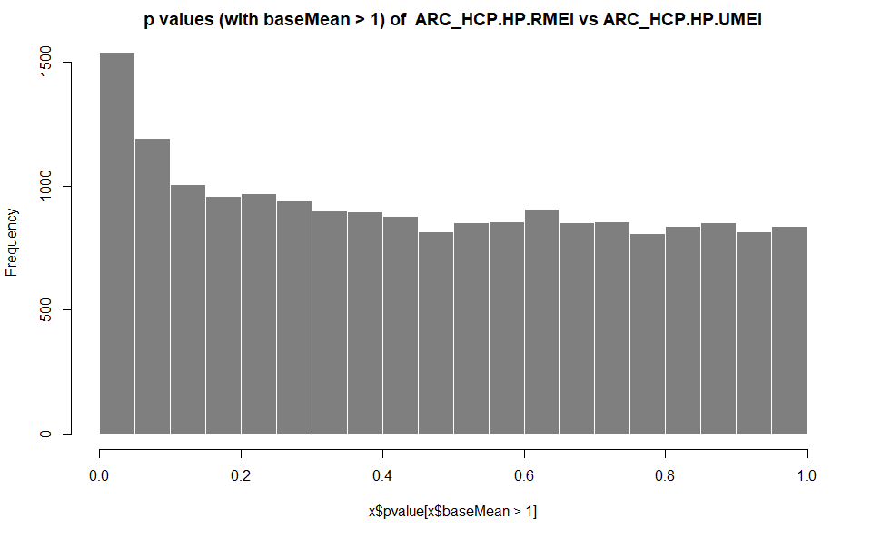

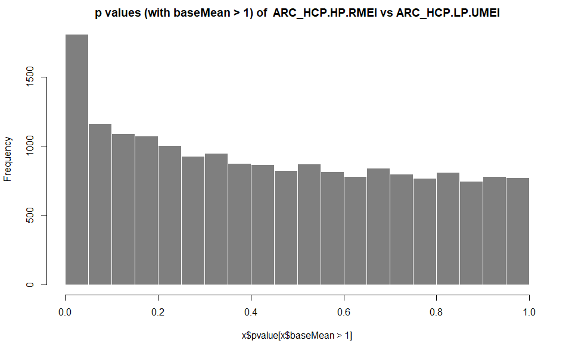

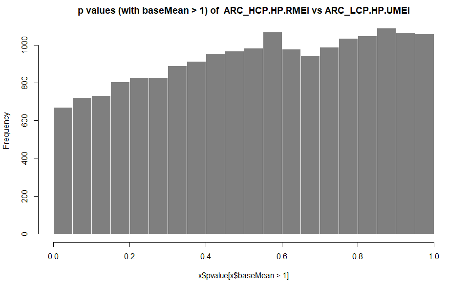

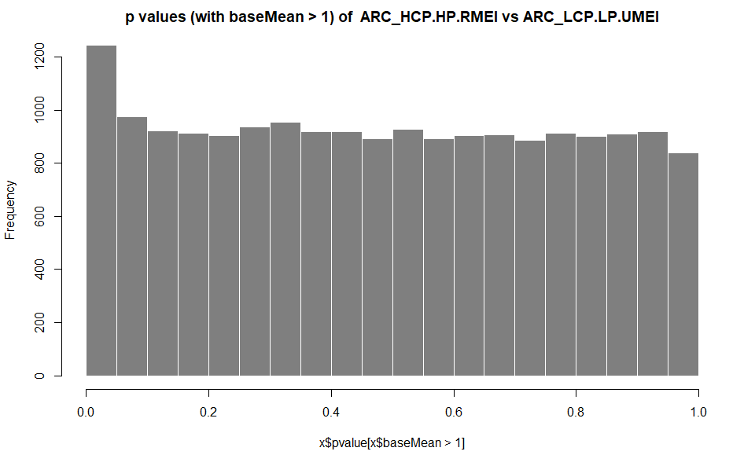

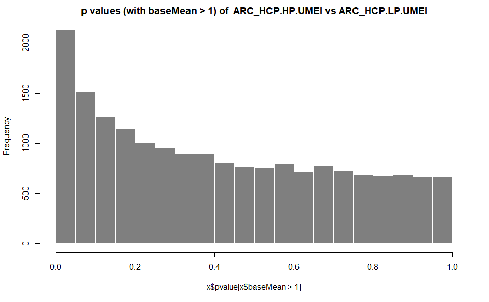

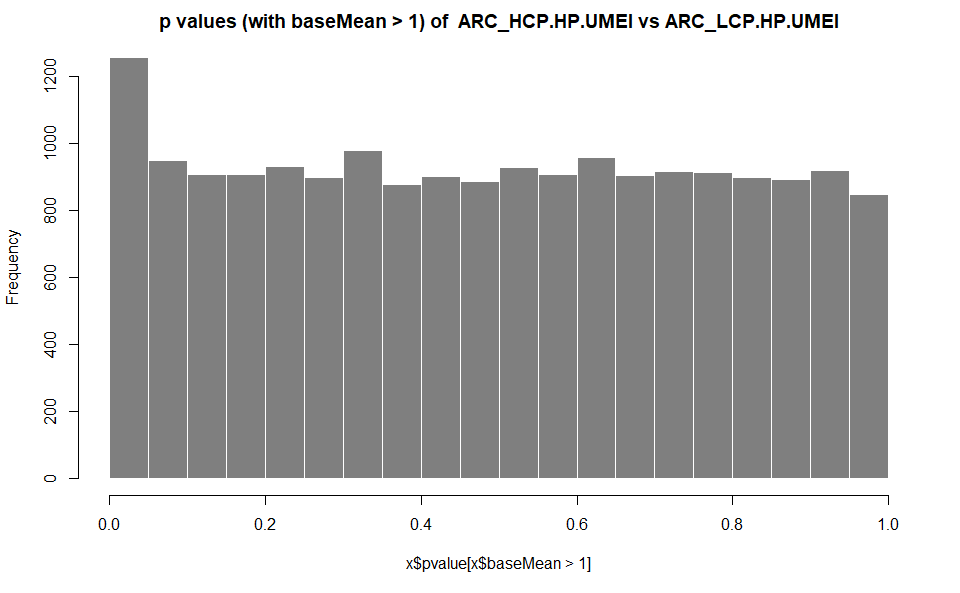

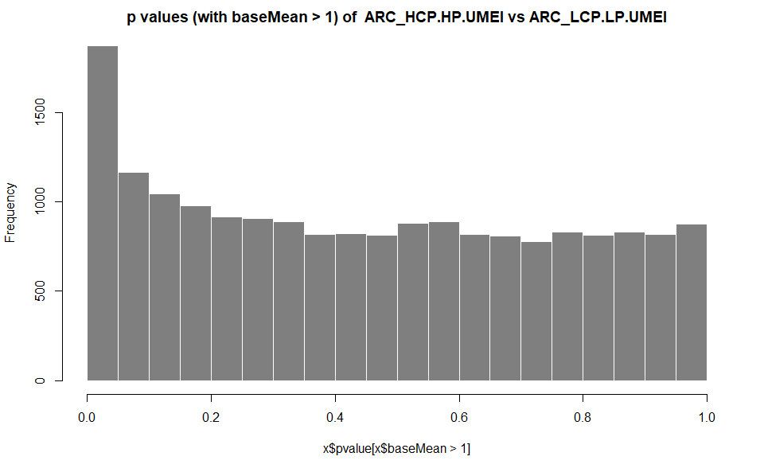

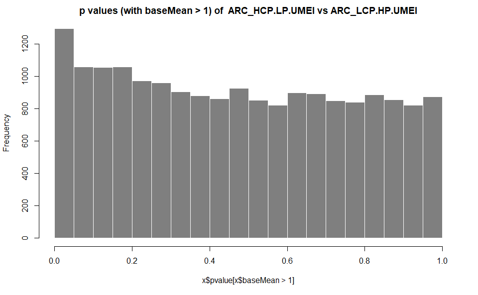

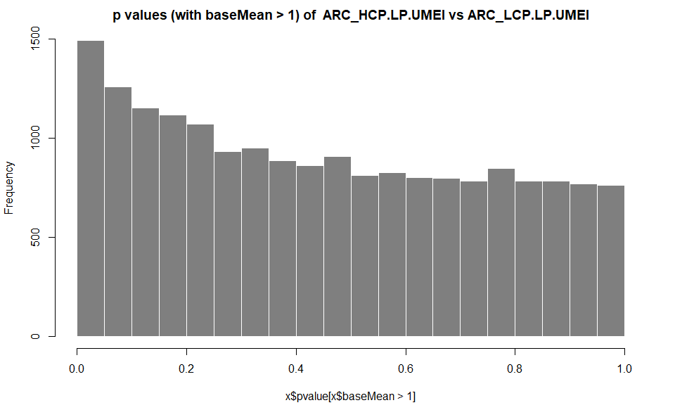

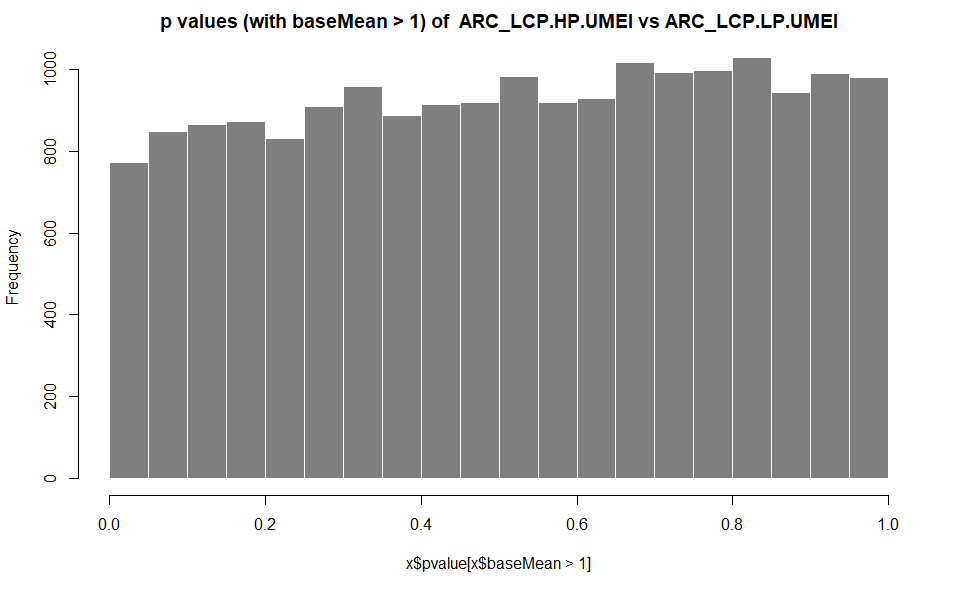

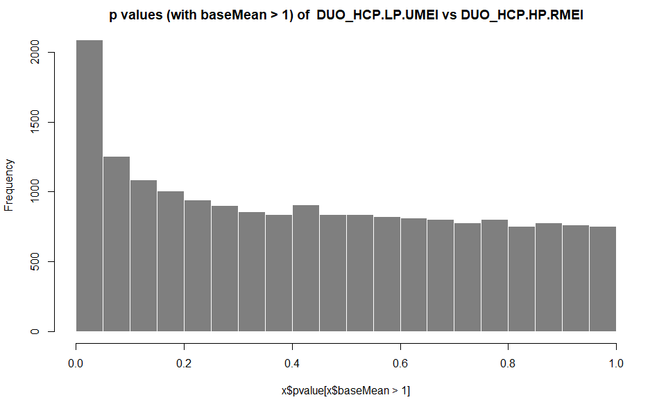

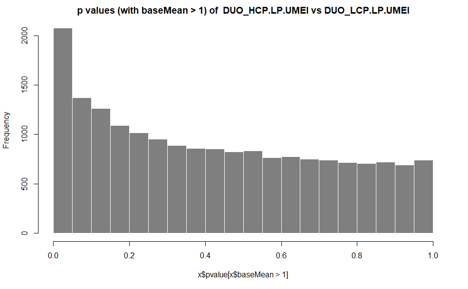

[8 more figures not shown]

```
$`ARC_DESeq2_Output.ARC_HCP.HP.RMEI vs ARC_HCP.HP.UMEI`
null device
          1

$`ARC_DESeq2_Output.ARC_HCP.HP.RMEI vs ARC_HCP.LP.UMEI`
null device
          1

$`ARC_DESeq2_Output.ARC_HCP.HP.RMEI vs ARC_LCP.HP.UMEI`
null device
          1

$`ARC_DESeq2_Output.ARC_HCP.HP.RMEI vs ARC_LCP.LP.UMEI`
null device
          1

$`ARC_DESeq2_Output.ARC_HCP.HP.UMEI vs ARC_HCP.LP.UMEI`
null device
          1

$`ARC_DESeq2_Output.ARC_HCP.HP.UMEI vs ARC_LCP.HP.UMEI`
null device
          1

$`ARC_DESeq2_Output.ARC_HCP.HP.UMEI vs ARC_LCP.LP.UMEI`
null device
          1

$`ARC_DESeq2_Output.ARC_HCP.LP.UMEI vs ARC_LCP.HP.UMEI`
null device
          1

$`ARC_DESeq2_Output.ARC_HCP.LP.UMEI vs ARC_LCP.LP.UMEI`
null device
          1

$`ARC_DESeq2_Output.ARC_LCP.HP.UMEI vs ARC_LCP.LP.UMEI`
null device
          1

```

[output cut: 24 more lines]

```
$`DUO_DESeq2_Output.DUO_HCP.HP.RMEI vs DUO_HCP.HP.UMEI`
null device
          1

$`DUO_DESeq2_Output.DUO_LCP.LP.UMEI vs DUO_LCP.HP.UMEI`
null device
          1

$`DUO_DESeq2_Output.DUO_LCP.LP.UMEI vs DUO_HCP.HP.UMEI`
null device
          1

$`DUO_DESeq2_Output.DUO_LCP.HP.UMEI vs DUO_HCP.HP.UMEI`
null device
          1
```

```r
#Store pvalue histograms into a new object
pvalue_plots_list <-
  DE_out %>%
  purrr::map("pairwise_plots") %>%
  purrr::map('Pvalue_histogram') %>%
  unlist(recursive = FALSE)

#View plots (Returned in output below this code chunk)

  pvalue_plots_list[1:20] %>%  #showing first 20 only
  purrr::map(function(x){
    print(x)
    plot.new()
    dev.off()
    })
```

#### MA Plots (for QC)

These are not the same MA plots which are generated with PIF, DE and annotations. This is rough plots from DESeq2.

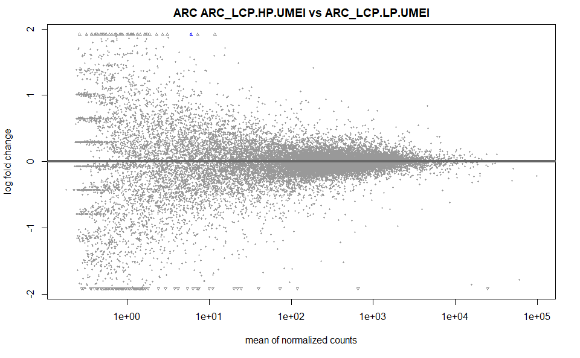

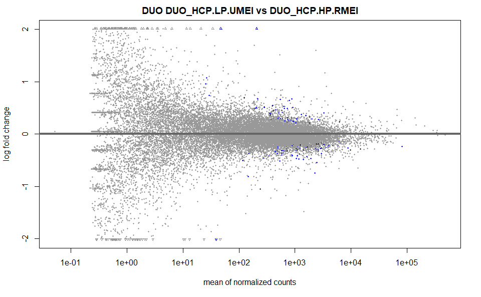

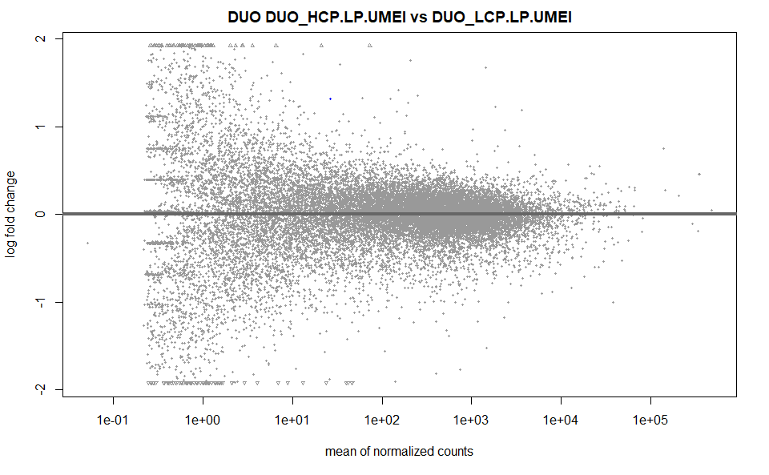

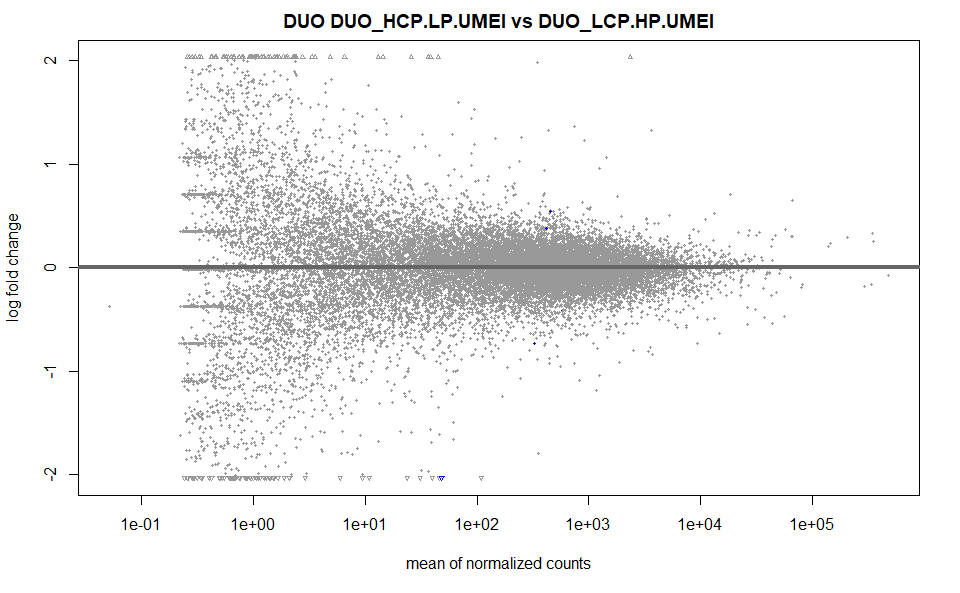

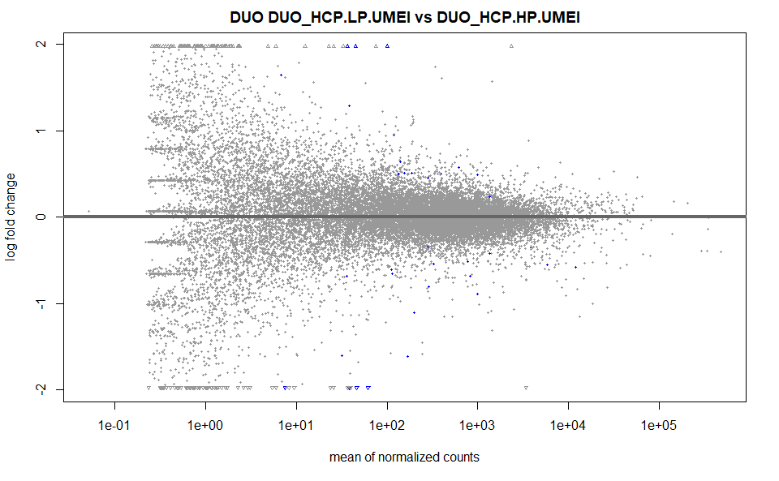

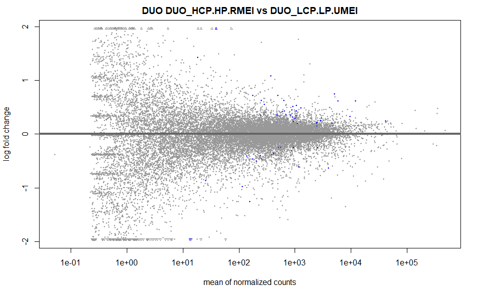

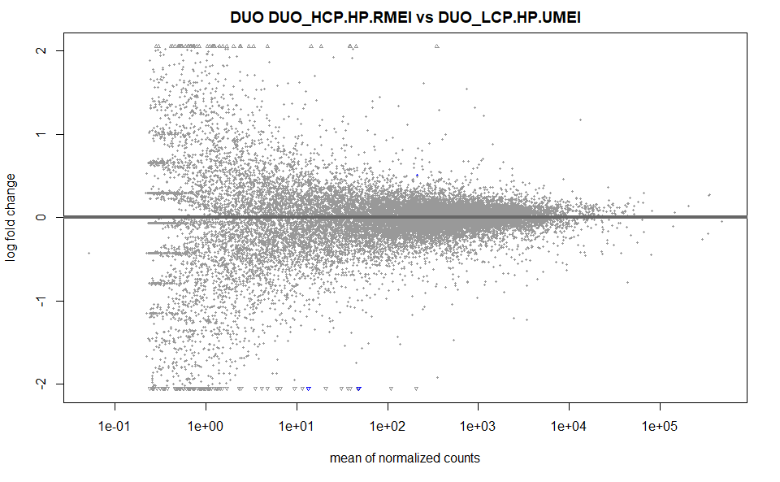

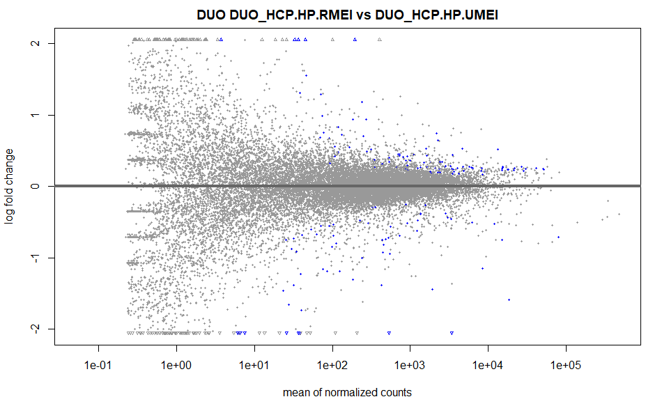

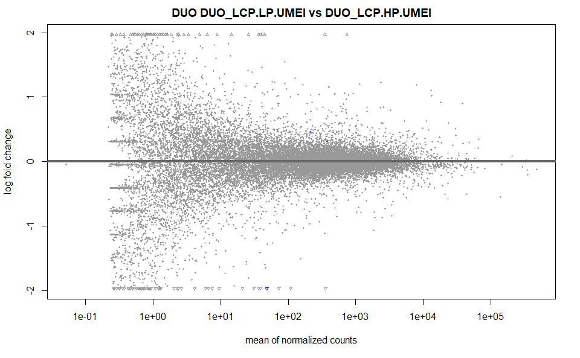

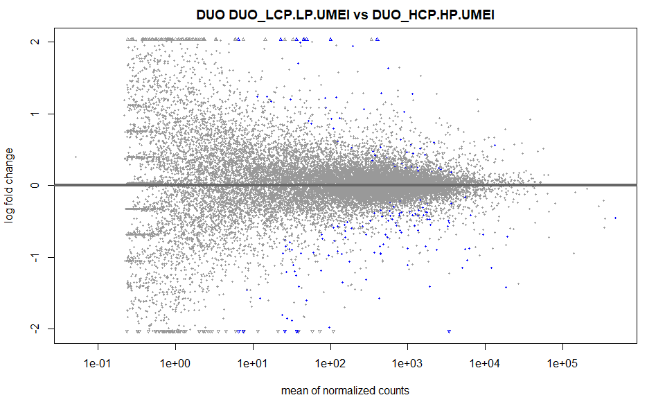

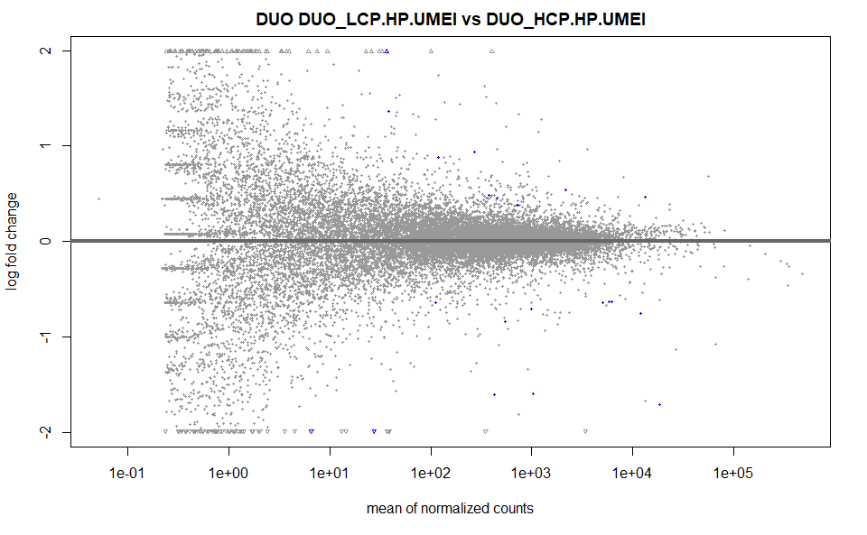

```
$`ARC_DESeq2_Output.ARC_LCP.HP.UMEI vs ARC_LCP.LP.UMEI`
null device
          1

$`DUO_DESeq2_Output.DUO_HCP.LP.UMEI vs DUO_HCP.HP.RMEI`
null device
          1

$`DUO_DESeq2_Output.DUO_HCP.LP.UMEI vs DUO_LCP.LP.UMEI`
null device
          1

$`DUO_DESeq2_Output.DUO_HCP.LP.UMEI vs DUO_LCP.HP.UMEI`
null device
          1

$`DUO_DESeq2_Output.DUO_HCP.LP.UMEI vs DUO_HCP.HP.UMEI`
null device
          1

$`DUO_DESeq2_Output.DUO_HCP.HP.RMEI vs DUO_LCP.LP.UMEI`
null device
          1

$`DUO_DESeq2_Output.DUO_HCP.HP.RMEI vs DUO_LCP.HP.UMEI`
null device
          1

$`DUO_DESeq2_Output.DUO_HCP.HP.RMEI vs DUO_HCP.HP.UMEI`
null device
          1

$`DUO_DESeq2_Output.DUO_LCP.LP.UMEI vs DUO_LCP.HP.UMEI`
null device
          1

$`DUO_DESeq2_Output.DUO_LCP.LP.UMEI vs DUO_HCP.HP.UMEI`
null device
          1

$`DUO_DESeq2_Output.DUO_LCP.HP.UMEI vs DUO_HCP.HP.UMEI`
null device
          1
```

```r
#Store pvalue histograms into a new object
MA_plots_list <-
  DE_out %>%
  purrr::map("pairwise_plots") %>%
  purrr::map('MA_plots') %>%
  unlist(recursive = FALSE)


#View plots (Returned in output below this code chunk)

  MA_plots_list[10:20] %>%  #showing 10 only
  purrr::map(function(x){
    print(x)
    plot.new()
    dev.off()
    })
```

### Overall Plots

```r
#View which overall plots are available to access
DE_out$ARC_DESeq2_Output$overall_plots %>% names()
```

```
[1] "heatmap"          "PCA"              "Sample_distances"
```

#### PCA

Some plots are in a different format (ggplots) and will show without function. e.g. the PCA plots

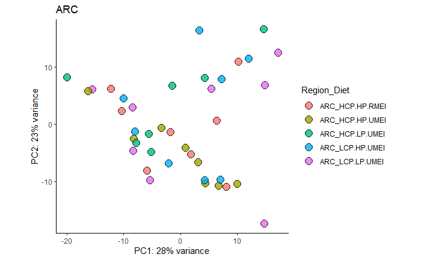

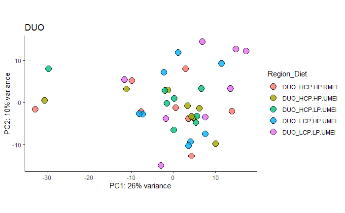

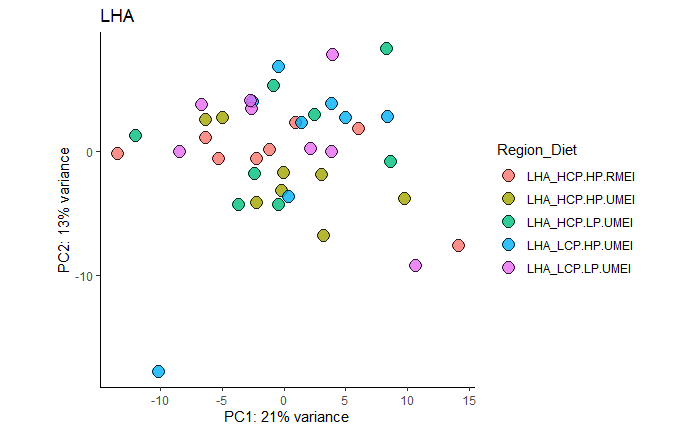

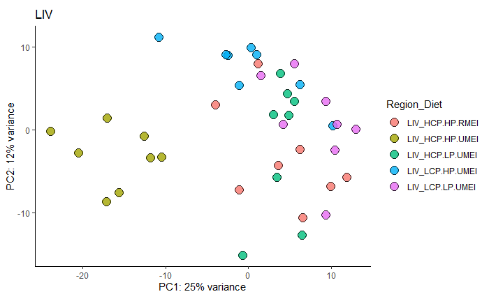

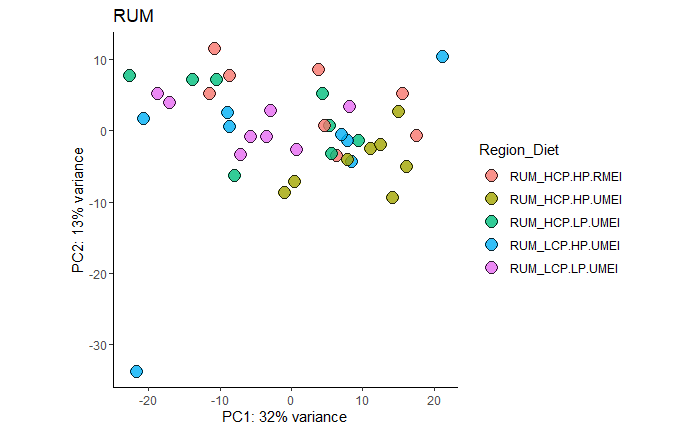

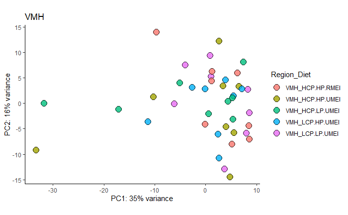

```r
#Store pvalue histograms into a new object
PCA_list <-
  DE_out %>%
  purrr::map("overall_plots") %>%
  purrr::map('PCA')

#View plots (Returned in output below this code chunk)
PCA_list
```

```r
NA
```

#### Heatmaps

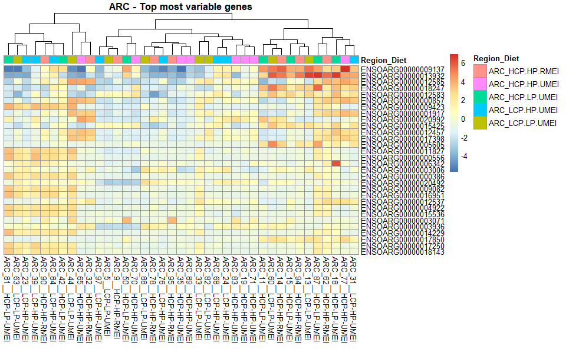

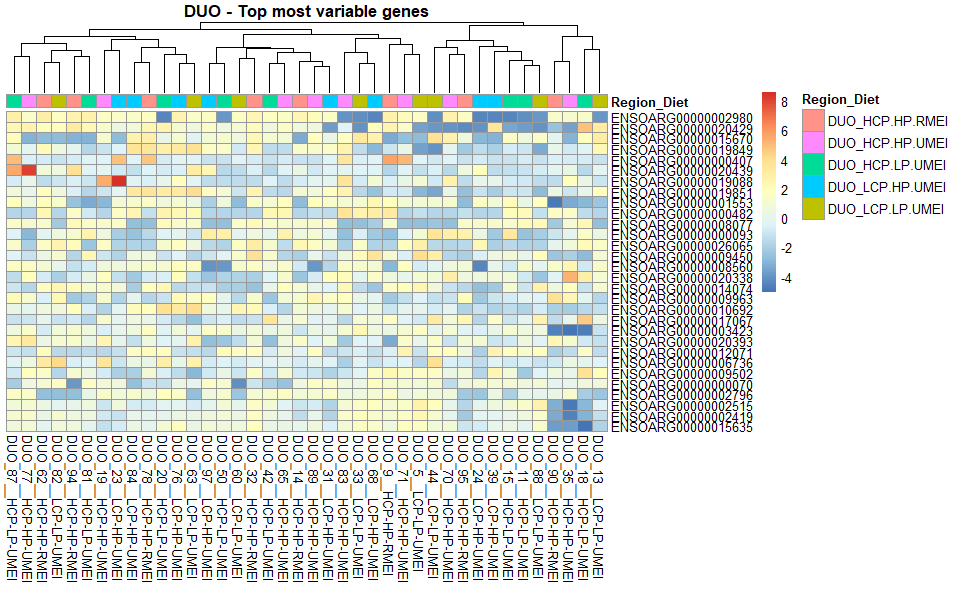

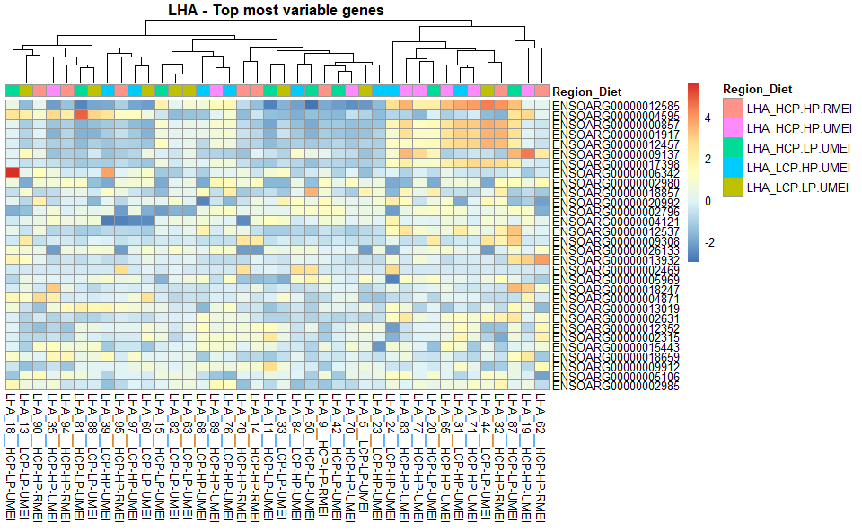

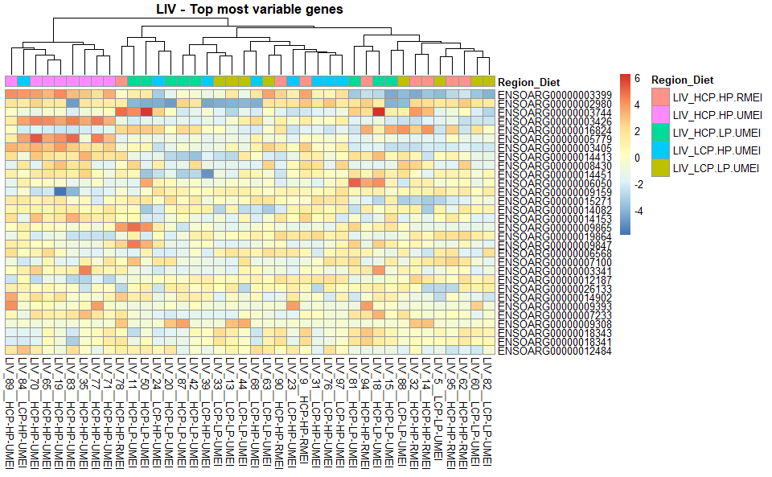

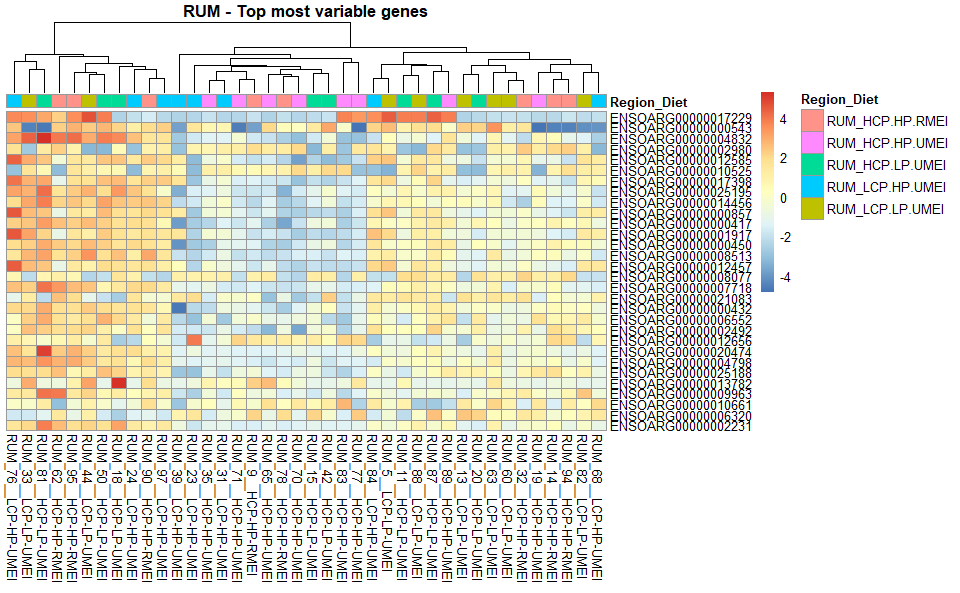

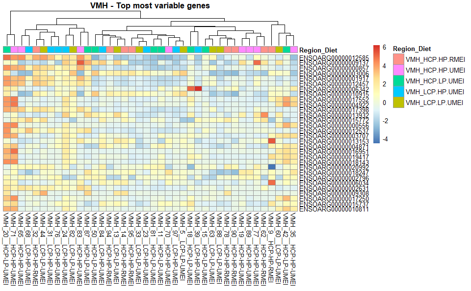

```r
#Store pvalue histograms into a new object
heatmaps <-
  DE_out %>%
  purrr::map("overall_plots") %>%
  purrr::map('heatmap')

#View plots (Returned in output below this code chunk)

  heatmaps %>%
  purrr::map(function(x){
    print(x)
    plot.new()
    dev.off()
    })
```

#### Sample-Sample Distances

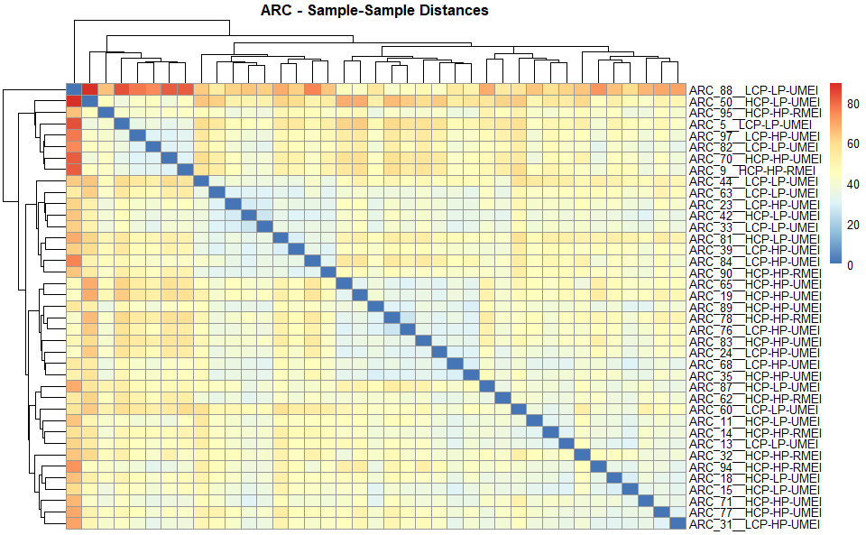

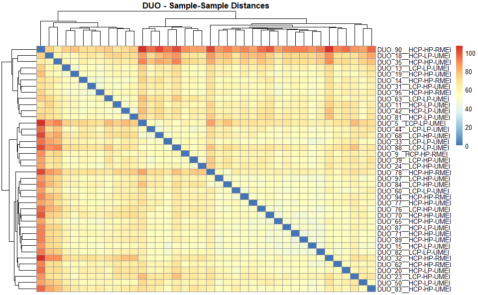

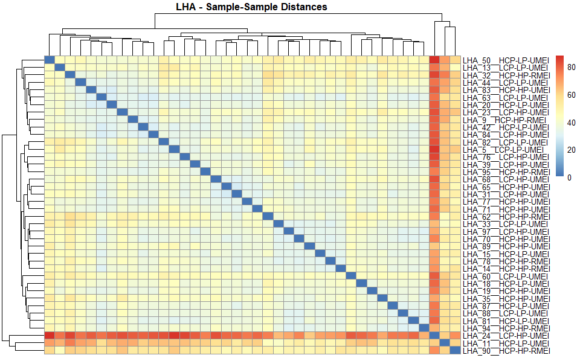

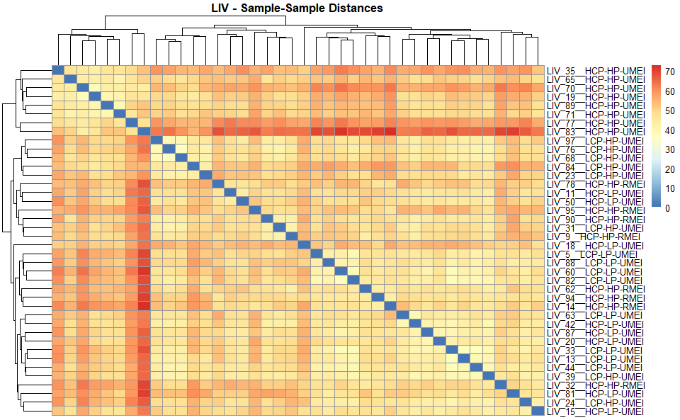

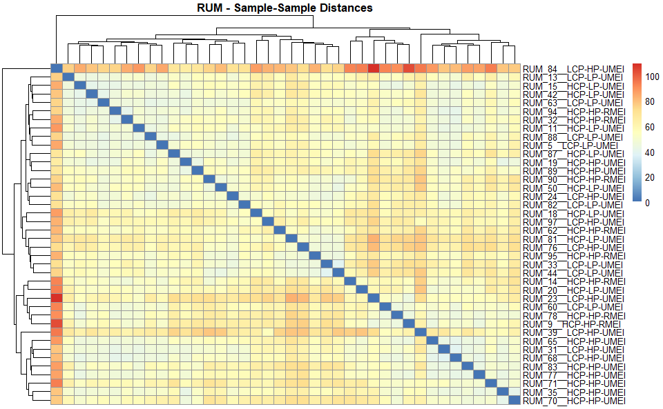

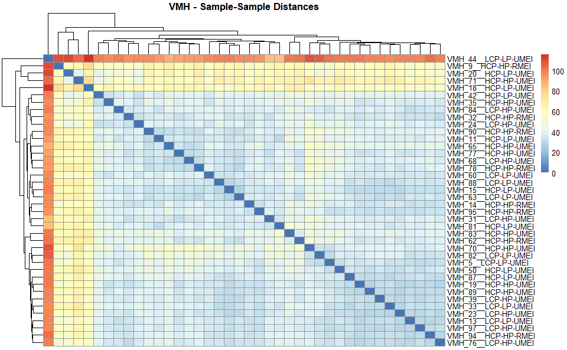

```r
#Store pvalue histograms into a new object
samp_dist_list <-
  DE_out %>%
  purrr::map("overall_plots") %>%
  purrr::map('Sample_distances')

#View plots (Returned in output below this code chunk)

  samp_dist_list %>%
  purrr::map(function(x){
    print(x)
    plot.new()
    dev.off()
    })
```

# 7. Filter and re-run

# 8. Generate whole dataset normalised counts

```r
full_norm <-
  auto_generate_DE_results(se_data = test_data,
                           top_level_name = Region,
                           column_of_samples = sample_names,
                           samples_to_remove = NA,
                           DESeq2_formula_design = ~Region_Diet,
                           gene_annotations = test_annot,
                           export_tables = TRUE,
                           export_dir = "./outputs/",
                           whole_data_normalisation = TRUE)
```

#Workign

```r
#testing how many have real names
 x %>%
        as.data.frame() %>%
        tibble::rownames_to_column(var = "gene_ensembl") %>%
        dplyr::left_join(annot, by = c("gene_ensembl")) %>%
        dplyr::select(.data$gene_ensembl,
                      .data$gene_name,
                      .data$description,
                      tidyselect::everything()) %>%
        arrange(.data$padj)
```

## Code for renaming old cts tables